# AET_v1_analysis_3

Author

Nikita

## Data

I have computed the analysis using a Quarto document in R. Here, I just have to upload the data files to the R project and specify a path for that so, if you run the analysis on your laptop the data might not load properly.

```r
library(tidyverse)
library(dplyr)

#Loading effort data
aetv1_beh_tib <- here::here("data","behav_summary_v1.csv") %>%
  readr::read_csv() %>%
  dplyr::filter(subjectNumber != 6) #excluding subject 6 due to experimental issues

#Loading questionnaire data
aetv1_questn_tib <- here::here("data","questionnaire_data_v1_analysis.csv") %>%
  readr::read_csv() %>%
  #Changing one of the numbers to 122
  dplyr::mutate(SubjectNumber = ifelse(SubjectNumber == 97759, 122, SubjectNumber)) %>%
  #For similarity in subjects numbers in both data sets
  dplyr::mutate(SubjectNumber = SubjectNumber - 100) %>%
  dplyr::filter(SubjectNumber != 6) #Excluding subject 6- same as effort data
```

## Cleaning effort data (behavioural)

```r
#Excluding participants with >95% acceptance rates and those based on failed accepted trials
aetv1_beh_tib <- aetv1_beh_tib %>%
  group_by(subjectNumber) %>%
  filter(response != 8888) %>%
  mutate(Mean_response = mean(response)) %>%
  filter(!(Mean_response > 0.95)) %>%
  mutate(failed = timeInWindow < 1) %>%
  mutate(failed = mean(failed, na.rm = T)) %>%
  filter(!(failed > 0.2))

# Removing missed trials and also if first and last trials were missed
aetv1_beh_tib$exertedEffortHistory[is.nan(aetv1_beh_tib$exertedEffortHistory)] <- 0
aetv1_beh_tib$exertedEffortHistory[aetv1_beh_tib$responseHistory == 8888] <- 0

#Calculating the acceptance rate by effort level and environment
aetv1_beh_tib$shapeEffort <- as.factor(aetv1_beh_tib$shapeEffort)
aetv1_beh_tib$blockType <- as.factor(aetv1_beh_tib$blockType)
aetv1_beh_tib_acceptrate <- aetv1_beh_tib %>%
  group_by(subjectNumber, blockType, shapeEffort) %>%
  summarise(acceptRate = mean(response))
#Renaming the Block column to Easy and Hard
aetv1_beh_tib_acceptrate <- aetv1_beh_tib_acceptrate %>%
   dplyr::mutate(blockType = stringr::str_to_sentence(blockType) %>% stringr::str_replace("11", "Easy") %>% stringr::str_replace("99", "Hard"))
```

## Scoring questionnaires

### Apathy-Motivation Index (AMI)

Paper referenced: [AMI](https://journals.plos.org/plosone/article?id=10.1371/journal.pone.0169938#sec002)

Level of apathy is assessed by taking the mean rating of the items within each subscale.

AMI: High scores indicate greater apathy and low scores indicate greater motivation

```r
#Selecting the columns for AMI
AMI <- aetv1_questn_tib %>%
  dplyr::select(AMI_1:AMI_18)
#Recoding the participant responses (All the items are reverse scored)
recode_AMI <- c("Completely UNTRUE" = 4, "Mostly untrue" = 3, "Neither true nor untrue" = 2, "Quite true" = 1, "Completely TRUE" = 0)
aetv1_questn_tib <- aetv1_questn_tib %>%
  dplyr::mutate(across(starts_with("AMI_"), ~ifelse(. %in% names(recode_AMI), recode_AMI[.], .))) %>%
  dplyr::mutate(across(starts_with("AMI_"), as.numeric))

#AMI Subscale total scores
#Emotional sensitivity (ES)
AMI_ES <- c("AMI_1", "AMI_6", "AMI_7", "AMI_13", "AMI_16", "AMI_18")
aetv1_questn_tib <- aetv1_questn_tib %>%
  mutate(AMI_ES_sum = rowMeans(dplyr::select(., all_of(AMI_ES)), na.rm = TRUE)) #Creating a new column with sum of scores for the ES subscale

#Social motivation (SM)
AMI_SM <- c("AMI_2", "AMI_3", "AMI_4", "AMI_8", "AMI_14", "AMI_17")
aetv1_questn_tib <- aetv1_questn_tib %>%
  mutate(AMI_SM_sum = rowMeans(dplyr::select(., all_of(AMI_SM)), na.rm = TRUE)) #Creating a new column with sum of scores for the SM subscale

#Behavioural activation (BA)
AMI_BA <- c("AMI_5", "AMI_9", "AMI_10", "AMI_11", "AMI_12", "AMI_15")
aetv1_questn_tib <- aetv1_questn_tib %>%
  mutate(AMI_BA_sum = rowMeans(dplyr::select(., all_of(AMI_BA)), na.rm = TRUE)) #Creating a new column with sum of scores for the BA subscale

#Total- full scale
aetv1_questn_tib <- aetv1_questn_tib %>%
  mutate(AMI_sum = rowMeans(cbind(AMI_ES_sum, AMI_SM_sum, AMI_BA_sum), na.rm = TRUE))
```

#### Histogram - AMI

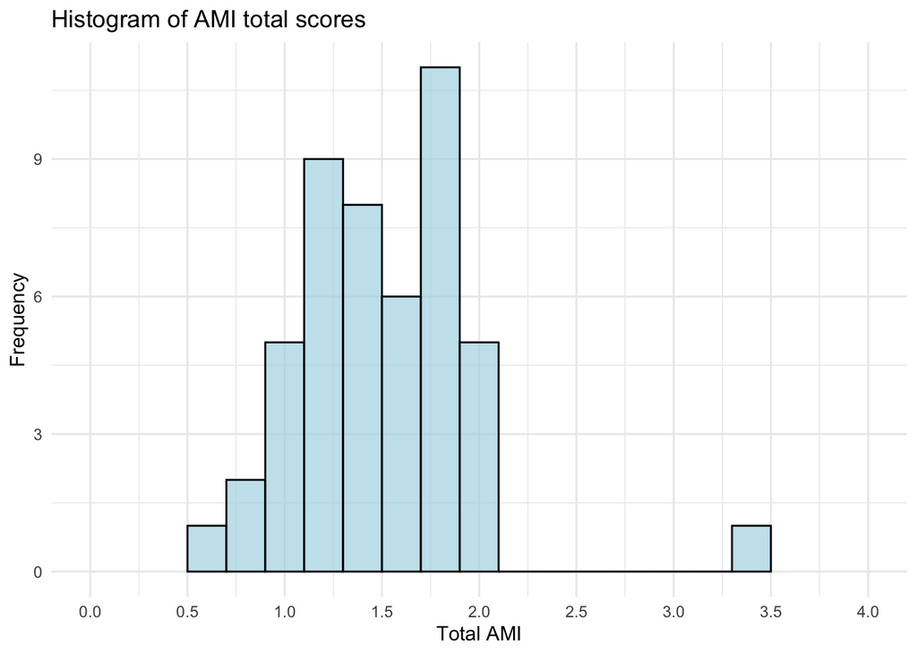

```r
library(ggplot2)
#Full-scale
ggplot(aetv1_questn_tib, aes(x = AMI_sum)) +
  geom_histogram(binwidth = 0.2, fill = "lightblue", color = "black", alpha = 0.7) +
  labs(title = "Histogram of AMI total scores", x = "Total AMI", y = "Frequency") +
  coord_cartesian(xlim = c(0,4)) +
  scale_x_continuous(breaks = seq(0, 4, 0.5)) +
  theme_minimal()
```

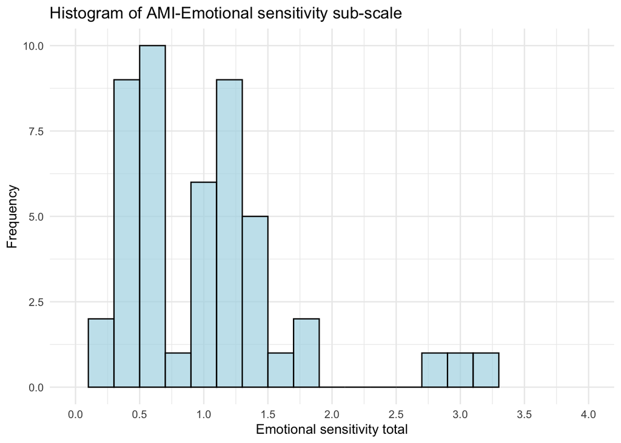

```r
#Emotional sensitivity sub-scale
ggplot(aetv1_questn_tib, aes(x = AMI_ES_sum)) +
  geom_histogram(binwidth = 0.2, fill = "lightblue", color = "black", alpha = 0.7) +
  labs(title = "Histogram of AMI-Emotional sensitivity sub-scale", x = "Emotional sensitivity total", y = "Frequency") +
  coord_cartesian(xlim = c(0,4)) +
  scale_x_continuous(breaks = seq(0, 4, 0.5)) +
  theme_minimal()
```

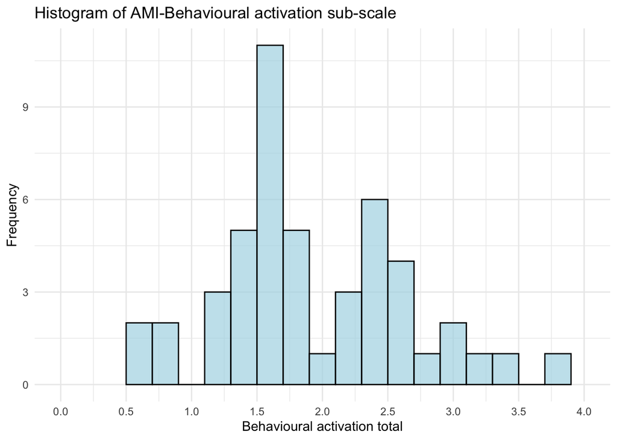

```r
#Behavioural activation sub-scale
ggplot(aetv1_questn_tib, aes(x = AMI_BA_sum)) +
  geom_histogram(binwidth = 0.2, fill = "lightblue", color = "black", alpha = 0.7) +
  labs(title = "Histogram of AMI-Behavioural activation sub-scale", x = "Behavioural activation total", y = "Frequency") +
  coord_cartesian(xlim = c(0,4)) +
  scale_x_continuous(breaks = seq(0, 4, 0.5)) +
  theme_minimal()
```

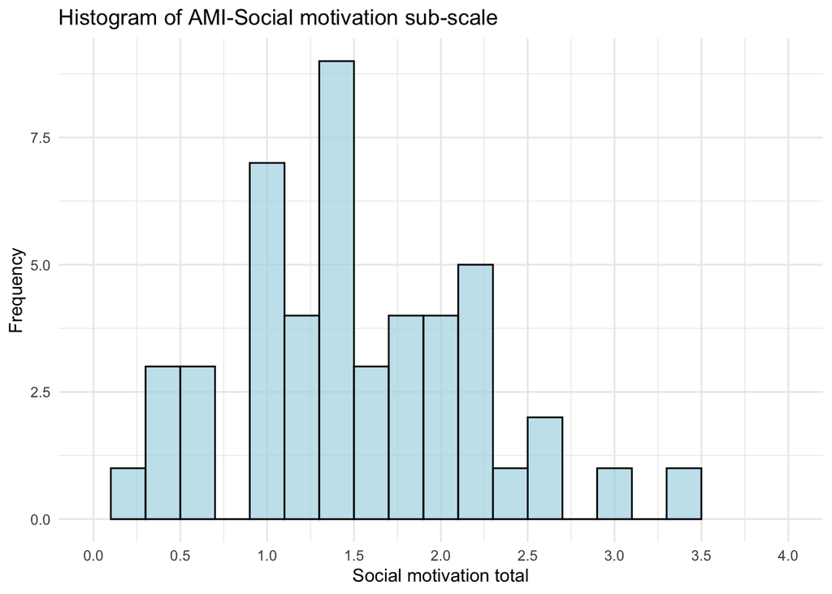

```r
#Social motivation sub-scale
ggplot(aetv1_questn_tib, aes(x = AMI_SM_sum)) +
  geom_histogram(binwidth = 0.2, fill = "lightblue", color = "black", alpha = 0.7) +
  labs(title = "Histogram of AMI-Social motivation sub-scale", x = "Social motivation total", y = "Frequency") +
  coord_cartesian(xlim = c(0,4)) +
  scale_x_continuous(breaks = seq(0, 4, 0.5)) +
  theme_minimal()
```

### Multidimensional Fatigue Inventory (MFI)

Papers referenced: [MFI](https://www.frontiersin.org/articles/10.3389/fpsyt.2022.1062426/full#B15)-1, [MFI](https://onlinelibrary.wiley.com/doi/pdfdirect/10.1046/j.1365-2354.2003.00295.x)-2

MFI: Higher scores indicate higher levels of fatigue

```r
#Selecting the columns for MFI
MFI <- aetv1_questn_tib %>%
  dplyr::select(MFI_1:MFI_20)

#Recoding the participant responses
recode_MFI <- c("1 - Yes, that is true" = 1, "5 - No, that is not true" = 5)
aetv1_questn_tib <- aetv1_questn_tib %>%
  mutate(across(starts_with("MFI_"), ~ifelse(. %in% names(recode_MFI), recode_MFI[.], .)))

#Reverse scoring the items
reverse_MFI <- c("5" = 1, "4" = 2, "3" = 3 ,"2" = 4, "1" = 5)
aetv1_questn_tib <- aetv1_questn_tib %>%
  dplyr::mutate(across(c("MFI_2", "MFI_5", "MFI_9", "MFI_10", "MFI_13", "MFI_14", "MFI_16", "MFI_17", "MFI_18", "MFI_19"),
      ~ recode(., !!!reverse_MFI),
      .names = "reversed_{.col}"))

#Adding up the scores (full-scale)
MFI_all <- c("MFI_1", "reversed_MFI_2", "MFI_3", "MFI_4", "reversed_MFI_5", "MFI_6", "MFI_7", "MFI_8", "reversed_MFI_9", "reversed_MFI_10","MFI_11", "MFI_12", "reversed_MFI_13", "reversed_MFI_14", "MFI_15", "reversed_MFI_16", "reversed_MFI_17", "reversed_MFI_18", "reversed_MFI_19", "MFI_20")
aetv1_questn_tib <- aetv1_questn_tib %>%
  mutate(across(all_of(MFI_all), as.numeric)) %>%
  mutate(MFI_sum = rowSums(dplyr::select(., all_of(MFI_all)), na.rm = TRUE))

#MFI Subscale sum
#General fatigue
MFI_genfatigue <- c("MFI_1", "reversed_MFI_5", "MFI_12", "reversed_MFI_16")
aetv1_questn_tib <- aetv1_questn_tib %>%
  mutate(across(all_of(MFI_genfatigue), as.numeric)) %>%
  mutate(MFI_genfatigue_sum = rowSums(dplyr::select(., all_of(MFI_genfatigue)), na.rm = TRUE))

#Physical fatigue
MFI_phyfatigue <- c("reversed_MFI_2", "MFI_8", "reversed_MFI_14", "MFI_20")
aetv1_questn_tib <- aetv1_questn_tib %>%
  mutate(across(all_of(MFI_phyfatigue), as.numeric)) %>%
  mutate(MFI_phyfatigue_sum = rowSums(dplyr::select(., all_of(MFI_phyfatigue)), na.rm = TRUE))

#Reduced activity
MFI_redactivity <- c("MFI_3", "MFI_6", "reversed_MFI_10", "reversed_MFI_17")
aetv1_questn_tib <- aetv1_questn_tib %>%
  mutate(across(all_of(MFI_redactivity), as.numeric)) %>%
  mutate(MFI_redactivity_sum = rowSums(dplyr::select(., all_of(MFI_redactivity)), na.rm = TRUE))

#Reduced motivation
MFI_redmotn <- c("MFI_4", "reversed_MFI_9", "MFI_15", "reversed_MFI_18")
aetv1_questn_tib <- aetv1_questn_tib %>%
  mutate(across(all_of(MFI_redmotn), as.numeric)) %>%
  mutate(MFI_redmotn_sum = rowSums(dplyr::select(., all_of(MFI_redmotn)), na.rm = TRUE))

#Mental fatigue
MFI_mentalfatigue <- c("MFI_7", "MFI_11", "reversed_MFI_13", "reversed_MFI_19")
aetv1_questn_tib <- aetv1_questn_tib %>%
  mutate(across(all_of(MFI_mentalfatigue), as.numeric)) %>%
  mutate(MFI_mentalfatigue_sum = rowSums(dplyr::select(., all_of(MFI_mentalfatigue)), na.rm = TRUE))
```

#### Histogram - MFI

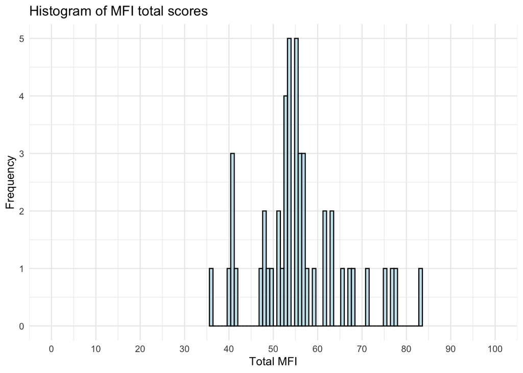

```r
#Full-scale
ggplot(aetv1_questn_tib, aes(x = MFI_sum)) +
  geom_histogram(binwidth = 0.8, fill = "lightblue", color = "black", alpha = 0.7) +
  labs(title = "Histogram of MFI total scores", x = "Total MFI", y = "Frequency") +
  coord_cartesian(xlim = c(0,100)) +
  scale_x_continuous(breaks = seq(0, 100, 10)) +
  theme_minimal()
```

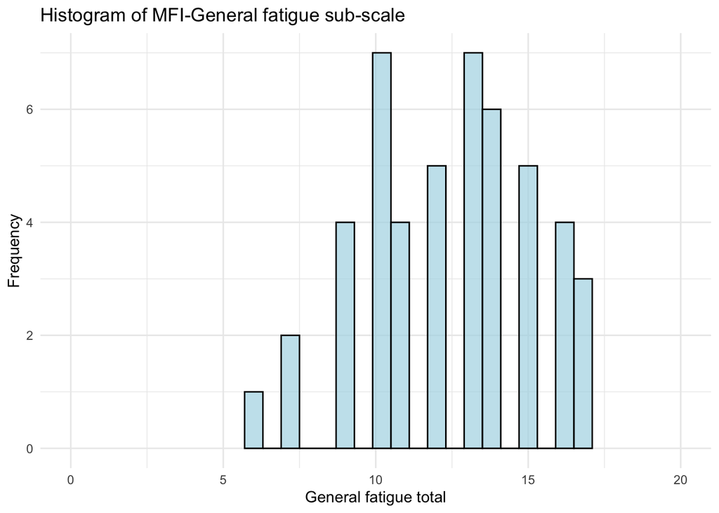

```r
#General fatigue sub-scale
ggplot(aetv1_questn_tib, aes(x = MFI_genfatigue_sum)) +
  geom_histogram(binwidth = 0.6, fill = "lightblue", color = "black", alpha = 0.7) +
  labs(title = "Histogram of MFI-General fatigue sub-scale", x = "General fatigue total", y = "Frequency") +
  coord_cartesian(xlim = c(0,20)) +
  scale_x_continuous(breaks = seq(0, 20, 5)) +
  theme_minimal()
```

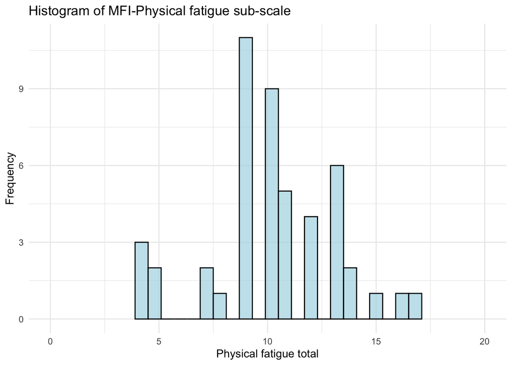

```r
#Physical fatigue sub-scale
ggplot(aetv1_questn_tib, aes(x = MFI_phyfatigue_sum)) +
  geom_histogram(binwidth = 0.6, fill = "lightblue", color = "black", alpha = 0.7) +
  labs(title = "Histogram of MFI-Physical fatigue sub-scale", x = "Physical fatigue total", y = "Frequency") +
  coord_cartesian(xlim = c(0,20)) +
  scale_x_continuous(breaks = seq(0, 20, 5)) +
  theme_minimal()
```

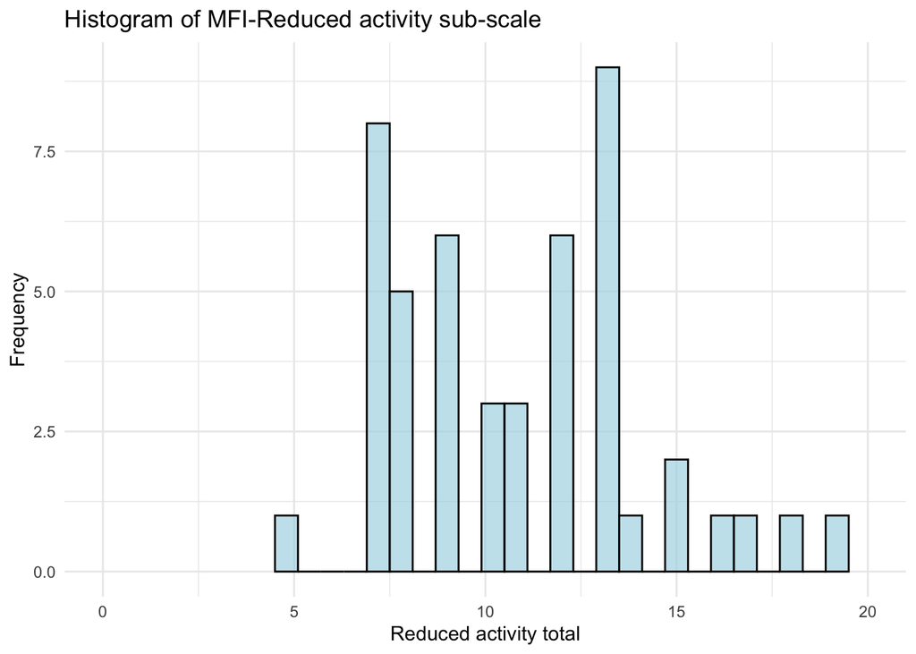

```r
#Reduced activity sub-scale
ggplot(aetv1_questn_tib, aes(x = MFI_redactivity_sum)) +
  geom_histogram(binwidth = 0.6, fill = "lightblue", color = "black", alpha = 0.7) +
  labs(title = "Histogram of MFI-Reduced activity sub-scale", x = "Reduced activity total", y = "Frequency") +
  coord_cartesian(xlim = c(0,20)) +
  scale_x_continuous(breaks = seq(0, 20, 5)) +
  theme_minimal()
```

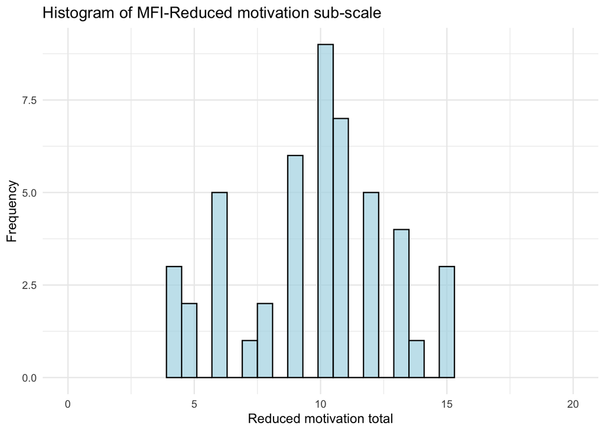

```r
#Reduced motivation sub-scale
ggplot(aetv1_questn_tib, aes(x = MFI_redmotn_sum)) +
  geom_histogram(binwidth = 0.6, fill = "lightblue", color = "black", alpha = 0.7) +
  labs(title = "Histogram of MFI-Reduced motivation sub-scale", x = "Reduced motivation total", y = "Frequency") +
  coord_cartesian(xlim = c(0,20)) +
  scale_x_continuous(breaks = seq(0, 20, 5)) +
  theme_minimal()
```

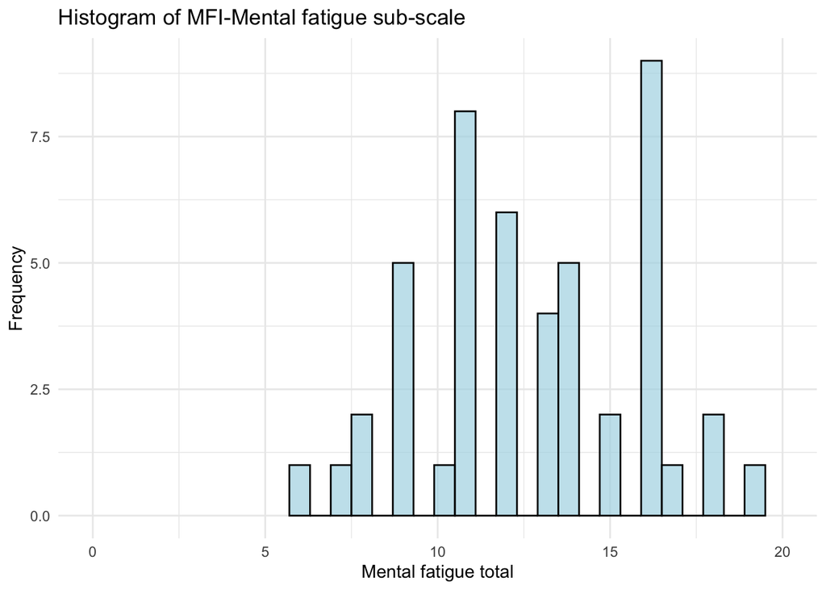

```r
#Mental fatigue sub-scale
ggplot(aetv1_questn_tib, aes(x = MFI_mentalfatigue_sum)) +
  geom_histogram(binwidth = 0.6, fill = "lightblue", color = "black", alpha = 0.7) +
  labs(title = "Histogram of MFI-Mental fatigue sub-scale", x = "Mental fatigue total", y = "Frequency") +
  coord_cartesian(xlim = c(0,20)) +
  scale_x_continuous(breaks = seq(0, 20, 5)) +
  theme_minimal()
```

### Snaith-Hamilton Pleasure Scale (SHAPS)

Paper referenced: [SHAPS](https://journals.plos.org/plosone/article?id=10.1371/journal.pone.0169938#sec002)

New reference: 0/1 scoring - https://www.ncbi.nlm.nih.gov/pmc/articles/PMC2957191/

```r
#Selecting columns
SHAPS <- aetv1_questn_tib %>%
  dplyr::select(SHAPS_1:SHAPS_14)

#Recoding the participant responses and adding them up
recode_SHAPS <- c("Strongly agree" = 0, "Agree" = 0, "Disagree" = 1, "Strongly disagree" = 1)
aetv1_questn_tib <- aetv1_questn_tib %>%
  mutate(across(starts_with("SHAPS_"), ~ifelse(. %in% names(recode_SHAPS), recode_SHAPS[.], .))) %>%
  mutate(across(starts_with("SHAPS_"), as.numeric)) %>%
  mutate(SHAPS_sum = rowSums(dplyr::select(., starts_with("SHAPS_")), na.rm = TRUE))
```

#### Histogram - SHAPS

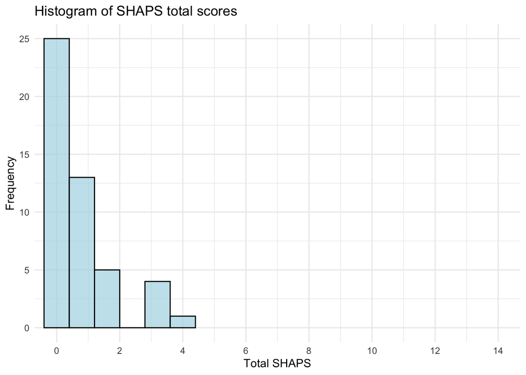

```r
#Full-scale
ggplot(aetv1_questn_tib, aes(x = SHAPS_sum)) +
  geom_histogram(binwidth = 0.8, fill = "lightblue", color = "black", alpha = 0.7) +
  labs(title = "Histogram of SHAPS total scores", x = "Total SHAPS", y = "Frequency") +
  coord_cartesian(xlim = c(0,14)) +
  scale_x_continuous(breaks = seq(0, 14, 2)) +
  theme_minimal()
```

### International Physical activity questionnaire (IPAQ)

[IPAQ](https://ugc.futurelearn.com/uploads/files/bc/c5/bcc53b14-ec1e-4d90-88e3-1568682f32ae/IPAQ_PDF.pdf) : Followed the following steps:

1. Convert all activity to minutes before calculating MET minutes.
2. It is recommended that activity bouts of greater than 3 hours are truncated.
3. To calculate MET minutes a week multiply the MET value given (remember walking = 3.3, moderate activity = 4, vigorous activity = 8) by the minutes the activity was carried out and again by the number of days that that activity was undertaken.
4. Add the MET minutes achieved in each category (walking, moderate activity and vigorous activity) to get total MET minutes of physical activity a week.

```r
#Recoding and scoring
library(stringr)
aetv1_questn_tib <- aetv1_questn_tib %>%
      mutate_at("IPAQ_1", str_replace, "days", "") %>%
      mutate_at("IPAQ_2", str_replace, "days", "") %>%
      mutate_at("IPAQ_3", str_replace, "days", "") %>%
      mutate_at("IPAQ_1", str_replace, "day", "") %>%
      mutate_at("IPAQ_2", str_replace, "day", "") %>%
      mutate_at("IPAQ_3", str_replace, "day", "")


#For the cells with a range, the mid value was used (for eg: "1 to 2 hours" = "90")
#The highest should be 180 mins so, for participants who mentioned more than 3 hrs, I recoded that to 180 mins (as that is the upper limit)

replacements_IPAQ_1a <- c("1 hour and 30 minutes" = "90", "1 hour 30 mins" = "90", "1 hour" = "60", "30min" = "30", "60 minutes" = "60", "30 mins" = "30", "0 hours 45 Minutes" = "45", "30 minutes" = "30", "30-60min" = "45", "2hrs" = "120", "1.5 hours" = "90", "2 hours" = "120", "3 hours" = "180", "45 minutes" = "45", "75 minutes" = "75")

replacements_IPAQ_2a <- c("1 hour 30 minutes" = "90", "1 hour each" = "60", "1 hour" = "60", "about two hours" = "120", "20 min" = "20", "1/2 hours" = "30", "1 to 2 hours" = "90", "40mins" = "40", "2 hours" = "120", "2hours" = "120", "1 Hour 0 Min" = "60", "1hr" = "60", "1 hours" = "60", "30 mins" = "30", "3 hours" = "180", "20 mins" = "20", "30 minutes" = "30")

replacements_IPAQ_3a <- c("30 minutes per day" = "30", "around 40 minutes probably" = "40", "40 mins - 1 hour" = "50", "1 hour 00 minutes" = "60", "2-3 hours" = "150", "1 hour" = "60", "about 70 minutes" = "70", "20 min" = "20", "1/2 hours" = "30", "6 to 7 hours" = "180", "30mins" = "30", "2 hours" = "120", "20 minutes" = "20", "40min" = "40", "one hour" = "60", "30 minutes" = "30", "30 min" = "30", "3 hours" = "180", "45 minutes" = "45", "30 mins" = "30", "30-60min or more" = "60", "3hrs" = "180", "1.5 hours" = "90", "30-40 minutes" = "35", "30-45 mins" = "37.5", "20 minutes" = "20", "40 minutes" = "40", "1hr" = "60", "4 hours" = "180")

aetv1_questn_tib <- aetv1_questn_tib %>%
  mutate(IPAQ_1a = case_when(IPAQ_1a %in% names(replacements_IPAQ_1a) ~ str_replace_all(IPAQ_1a, setNames(replacements_IPAQ_1a, paste0("\\b", names(replacements_IPAQ_1a), "\\b"))), TRUE ~ IPAQ_1a))

aetv1_questn_tib <- aetv1_questn_tib %>%
  mutate(IPAQ_2a = case_when(IPAQ_2a %in% names(replacements_IPAQ_2a) ~ str_replace_all(IPAQ_2a, setNames(replacements_IPAQ_2a, paste0("\\b", names(replacements_IPAQ_2a), "\\b"))), TRUE ~ IPAQ_2a))

aetv1_questn_tib <- aetv1_questn_tib %>%
  mutate(IPAQ_3a = case_when(IPAQ_3a %in% names(replacements_IPAQ_3a) ~ str_replace_all(IPAQ_3a, setNames(replacements_IPAQ_3a, paste0("\\b", names(replacements_IPAQ_3a), "\\b"))), TRUE ~ IPAQ_3a))

#Calculating MET for each activity
aetv1_questn_tib <- aetv1_questn_tib %>%
  mutate(IPAQ_1 = as.numeric(IPAQ_1),
    IPAQ_1a = as.numeric(IPAQ_1a),
    IPAQ_2 = as.numeric(IPAQ_2),
    IPAQ_2a = as.numeric(IPAQ_2a),
    IPAQ_3 = as.numeric(IPAQ_3),
    IPAQ_3a = as.numeric(IPAQ_3a),
    IPAQ_vigorous = IPAQ_1 * IPAQ_1a * 8,
    IPAQ_moderate = IPAQ_2 * IPAQ_2a * 4,
    IPAQ_walking = IPAQ_3 * IPAQ_3a * 3.3)

#Total MET
aetv1_questn_tib <- aetv1_questn_tib %>%
  mutate(IPAQ_MET = rowSums(dplyr::select(., IPAQ_vigorous, IPAQ_moderate, IPAQ_walking), na.rm = TRUE))
```

## Reliability of the scales

Performing a cronbach’s alpha here to check for the internal consistency of the used scales and their sub-scales.

### AMI

```r
#AMI
AMI_alpha <- aetv1_questn_tib %>%
  dplyr::select("AMI_1", "AMI_2", "AMI_3", "AMI_4", "AMI_5", "AMI_6", "AMI_7", "AMI_8", "AMI_9", "AMI_10", "AMI_11", "AMI_12", "AMI_13", "AMI_14", "AMI_15", "AMI_16", "AMI_17", "AMI_18")
ltm::cronbach.alpha(AMI_alpha)
```

```
Cronbach's alpha for the 'AMI_alpha' data-set

Items: 18
Sample units: 48
alpha: 0.734
```

```r
#AMI_ES
AMI_ES_alpha <- aetv1_questn_tib  %>%
  dplyr::select("AMI_1", "AMI_6", "AMI_7", "AMI_13", "AMI_16", "AMI_18")
ltm::cronbach.alpha(AMI_ES_alpha)
```

```
Cronbach's alpha for the 'AMI_ES_alpha' data-set

Items: 6
Sample units: 48
alpha: 0.748
```

```r
#AMI_SM
AMI_SM_alpha <- aetv1_questn_tib  %>%
  dplyr::select("AMI_2", "AMI_3", "AMI_4", "AMI_8", "AMI_14", "AMI_17")
ltm::cronbach.alpha(AMI_SM_alpha)
```

```
Cronbach's alpha for the 'AMI_SM_alpha' data-set

Items: 6
Sample units: 48
alpha: 0.683
```

```r
#AMI_BA
AMI_BA_alpha <- aetv1_questn_tib  %>%
  dplyr::select("AMI_5", "AMI_9", "AMI_10", "AMI_11", "AMI_12", "AMI_15")
ltm::cronbach.alpha(AMI_BA_alpha)
```

```
Cronbach's alpha for the 'AMI_BA_alpha' data-set

Items: 6
Sample units: 48
alpha: 0.743
```

### MFI

```r
#MFI
MFI_alpha <- aetv1_questn_tib  %>%
  dplyr::select(all_of(MFI_all))
ltm::cronbach.alpha(MFI_alpha)
```

```
Cronbach's alpha for the 'MFI_alpha' data-set

Items: 20
Sample units: 48
alpha: 0.839
```

```r
#MFI_GF
MFI_GF_alpha <- aetv1_questn_tib  %>%
  dplyr::select(all_of(MFI_genfatigue))
ltm::cronbach.alpha(MFI_GF_alpha)
```

```
Cronbach's alpha for the 'MFI_GF_alpha' data-set

Items: 4
Sample units: 48
alpha: 0.643
```

```r
#MFI_PF
MFI_PF_alpha <- aetv1_questn_tib  %>%
  dplyr::select(all_of(MFI_phyfatigue))
ltm::cronbach.alpha(MFI_PF_alpha)
```

```
Cronbach's alpha for the 'MFI_PF_alpha' data-set

Items: 4
Sample units: 48
alpha: 0.735
```

```r
#MFI_RA
MFI_RA_alpha <- aetv1_questn_tib  %>%
  dplyr::select(all_of(MFI_redactivity))
ltm::cronbach.alpha(MFI_RA_alpha)
```

```
Cronbach's alpha for the 'MFI_RA_alpha' data-set

Items: 4
Sample units: 48
alpha: 0.799
```

```r
#MFI_RM
MFI_RM_alpha <- aetv1_questn_tib  %>%
  dplyr::select(all_of(MFI_redmotn))
ltm::cronbach.alpha(MFI_RM_alpha)
```

```
Cronbach's alpha for the 'MFI_RM_alpha' data-set

Items: 4
Sample units: 48
alpha: 0.731
```

```r
#MFI_MF
MFI_MF_alpha <- aetv1_questn_tib  %>%
  dplyr::select(all_of(MFI_mentalfatigue))
ltm::cronbach.alpha(MFI_MF_alpha)
```

```
Cronbach's alpha for the 'MFI_MF_alpha' data-set

Items: 4
Sample units: 48
alpha: 0.723
```

### SHAPS

```r
#SHAPS
SHAPS_alpha <- aetv1_questn_tib  %>%
  dplyr::select(SHAPS_1:SHAPS_14)
ltm::cronbach.alpha(SHAPS_alpha)
```

```
Cronbach's alpha for the 'SHAPS_alpha' data-set

Items: 14
Sample units: 48
alpha: 0.422
```

### IPAQ

Computing an alpha for this does not make sense right?

## Merging the 2 data sets

Performing a left merge (the data sets will be merged by the common column of ‘subject numbers’ in the 2 files) so that, the data from the questionnaires will be merged based on the cleaned effort data. This will drop all the subjects from the questionnaire data that were removed from the effort data during cleaning.

```r
#Removing the same participants as behavioural data from the questionnaires
AET_behandquestn_tib <- merge(aetv1_beh_tib_acceptrate, aetv1_questn_tib, by.x = "subjectNumber", by.y = "SubjectNumber", all.x = TRUE, all.y = FALSE)

#Viewing the first 10 rows for reference
AET_behandquestn_tib %>%
  head(10) %>%
  knitr::kable (digits = 2)
```

| subjectNumber | blockType | shapeEffort | acceptRate | Unique Response Number | Age | Gender | Student | Programme_and_year | AMI | AMI_1 | AMI_2 | AMI_3 | AMI_4 | AMI_5 | AMI_6 | AMI_7 | AMI_8 | AMI_9 | AMI_10 | AMI_11 | AMI_12 | AMI_13 | AMI_14 | AMI_15 | AMI_16 | AMI_17 | AMI_18 | MFI | MFI_1 | … |
| --- | --- | --- | --- | --- | --- | --- | --- | --- | --- | --- | --- | --- | --- | --- | --- | --- | --- | --- | --- | --- | --- | --- | --- | --- | --- | --- | --- | --- | --- | --- |
| 1 | Easy | 0.2 | 0.98 | 966465-966447-101567668 | 18 | Female | Yes | Psychology in Education; 1st | NA | 1 | 3 | 4 | 3 | 2 | 3 | 1 | 4 | 2 | 3 | 1 | 1 | 0 | 3 | 2 | 1 | 1 | 1 | NA | 2 | … |
| 1 | Easy | 0.4 | 0.79 | 966465-966447-101567668 | 18 | Female | Yes | Psychology in Education; 1st | NA | 1 | 3 | 4 | 3 | 2 | 3 | 1 | 4 | 2 | 3 | 1 | 1 | 0 | 3 | 2 | 1 | 1 | 1 | NA | 2 | … |
| 1 | Easy | 0.6 | 0.05 | 966465-966447-101567668 | 18 | Female | Yes | Psychology in Education; 1st | NA | 1 | 3 | 4 | 3 | 2 | 3 | 1 | 4 | 2 | 3 | 1 | 1 | 0 | 3 | 2 | 1 | 1 | 1 | NA | 2 | … |
| 1 | Hard | 0.2 | 0.95 | 966465-966447-101567668 | 18 | Female | Yes | Psychology in Education; 1st | NA | 1 | 3 | 4 | 3 | 2 | 3 | 1 | 4 | 2 | 3 | 1 | 1 | 0 | 3 | 2 | 1 | 1 | 1 | NA | 2 | … |
| 1 | Hard | 0.4 | 0.91 | 966465-966447-101567668 | 18 | Female | Yes | Psychology in Education; 1st | NA | 1 | 3 | 4 | 3 | 2 | 3 | 1 | 4 | 2 | 3 | 1 | 1 | 0 | 3 | 2 | 1 | 1 | 1 | NA | 2 | … |
| 1 | Hard | 0.6 | 0.29 | 966465-966447-101567668 | 18 | Female | Yes | Psychology in Education; 1st | NA | 1 | 3 | 4 | 3 | 2 | 3 | 1 | 4 | 2 | 3 | 1 | 1 | 0 | 3 | 2 | 1 | 1 | 1 | NA | 2 | … |
| 2 | Easy | 0.2 | 0.93 | 966465-966447-101575513 | 19 | Female | Yes | BSc Psychology in Education | NA | 0 | 0 | 2 | 1 | 3 | 1 | 2 | 4 | 1 | 0 | 1 | 1 | 0 | 1 | 1 | 1 | 1 | 0 | NA | 3 | … |
| 2 | Easy | 0.4 | 0.83 | 966465-966447-101575513 | 19 | Female | Yes | BSc Psychology in Education | NA | 0 | 0 | 2 | 1 | 3 | 1 | 2 | 4 | 1 | 0 | 1 | 1 | 0 | 1 | 1 | 1 | 1 | 0 | NA | 3 | … |
| 2 | Easy | 0.6 | 0.72 | 966465-966447-101575513 | 19 | Female | Yes | BSc Psychology in Education | NA | 0 | 0 | 2 | 1 | 3 | 1 | 2 | 4 | 1 | 0 | 1 | 1 | 0 | 1 | 1 | 1 | 1 | 0 | NA | 3 | … |
| 2 | Hard | 0.2 | 0.90 | 966465-966447-101575513 | 19 | Female | Yes | BSc Psychology in Education | NA | 0 | 0 | 2 | 1 | 3 | 1 | 2 | 4 | 1 | 0 | 1 | 1 | 0 | 1 | 1 | 1 | 1 | 0 | NA | 3 | … |

## Summary statistics

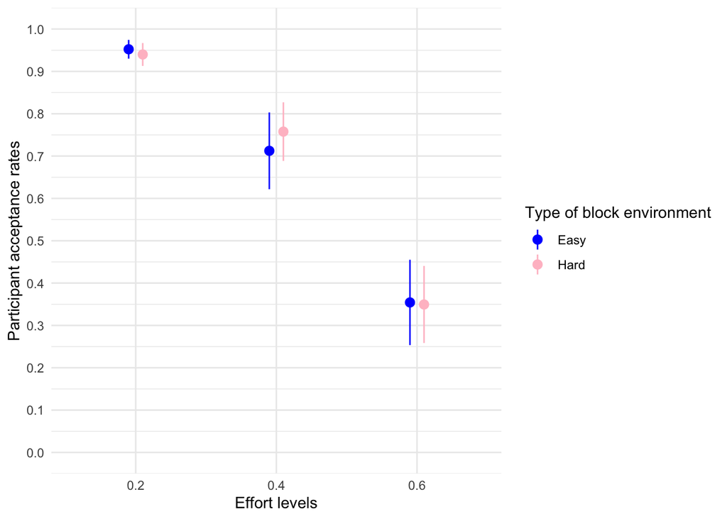

```r
library(Hmisc)

#Mean and CI of the effort data (Table)
mean_aetv1_beh <- AET_behandquestn_tib %>%
  dplyr::group_by(blockType, shapeEffort) %>%
  dplyr::summarize(
    n = n(),
    mean_accept = mean(acceptRate),
    LCI_accept = ggplot2::mean_cl_normal(acceptRate)$ymin,
    UCI_accept = ggplot2::mean_cl_normal(acceptRate)$ymax
  )

#Mean Plot for effort data
aetv1_plot1 <- ggplot2::ggplot(AET_behandquestn_tib, aes(x = shapeEffort, y= acceptRate, colour = blockType)) +
  stat_summary(fun.data = "mean_cl_normal", geom = "pointrange", position = position_dodge(width = 0.2)) +
  coord_cartesian(ylim = c(0,1)) +
  scale_y_continuous(breaks = seq(0, 1, 0.1)) +
  labs(x = "Effort levels", y = "Participant acceptance rates", colour = "Type of block environment") +
  scale_color_manual(values = c("Easy" = "blue", "Hard" = "pink")) +
  theme_minimal()
aetv1_plot1
```

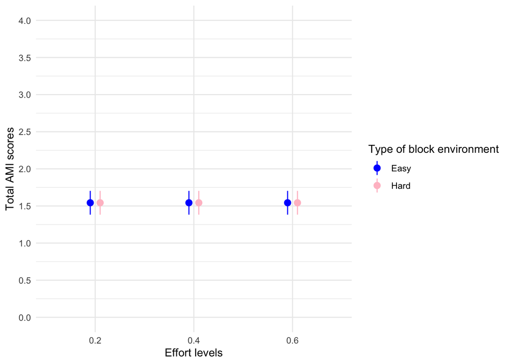

```r
#Mean and CI of the questionnaire scores

#AMI and sub-scales (Table)
mean_aetv1_AMI <- AET_behandquestn_tib %>%
  dplyr::group_by(blockType, shapeEffort) %>%
  dplyr::summarize(
    n = n(),
    mean_AMI = mean(AMI_sum),
    LCI_AMI = ggplot2::mean_cl_normal(AMI_sum)$ymin,
    UCI_AMI = ggplot2::mean_cl_normal(AMI_sum)$ymax,
    mean_AMI_ES = mean(AMI_ES_sum),
    LCI_AMI_ES = ggplot2::mean_cl_normal(AMI_ES_sum)$ymin,
    UCI_AMI_ES = ggplot2::mean_cl_normal(AMI_ES_sum)$ymax,
    mean_AMI_SM = mean(AMI_SM_sum),
    LCI_AMI_SM = ggplot2::mean_cl_normal(AMI_SM_sum)$ymin,
    UCI_AMI_SM = ggplot2::mean_cl_normal(AMI_SM_sum)$ymax,
    mean_AMI_BA = mean(AMI_BA_sum),
    LCI_AMI_BA = ggplot2::mean_cl_normal(AMI_BA_sum)$ymin,
    UCI_AMI_BA = ggplot2::mean_cl_normal(AMI_BA_sum)$ymax,
  )

#Mean plot- AMI
aetv1_plot2 <- ggplot2::ggplot(AET_behandquestn_tib, aes(x = shapeEffort, y= AMI_sum, colour = blockType)) +
  stat_summary(fun.data = "mean_cl_normal", geom = "pointrange", position = position_dodge(width = 0.2)) +
  coord_cartesian(ylim = c(0,4)) +
  scale_y_continuous(breaks = seq(0, 4, 0.5)) +
  labs(x = "Effort levels", y = "Total AMI scores", colour = "Type of block environment") +
  scale_color_manual(values = c("Easy" = "blue", "Hard" = "pink")) +
  theme_minimal()
aetv1_plot2
```

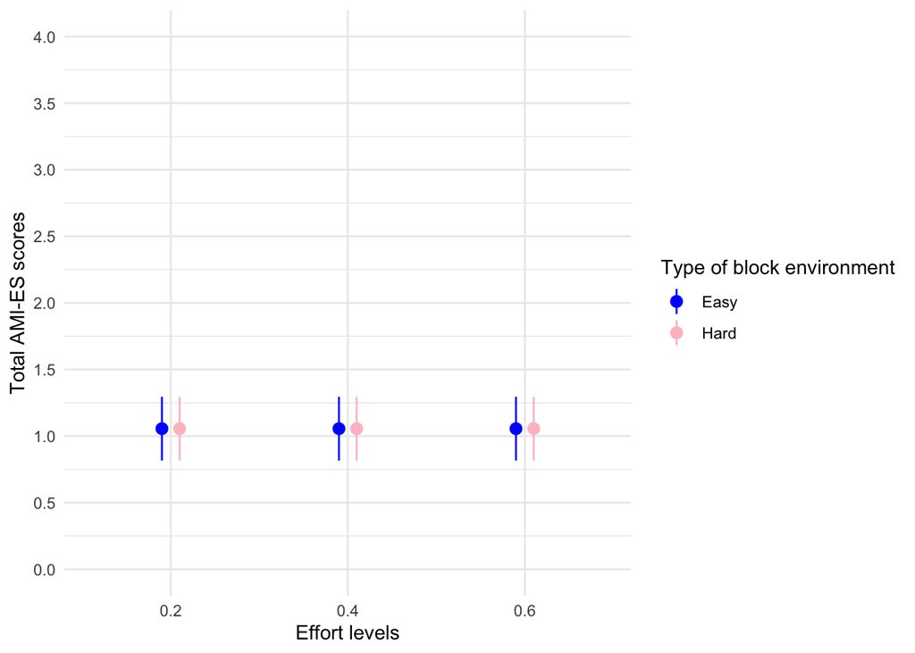

```r
aetv1_plot3 <- ggplot2::ggplot(AET_behandquestn_tib, aes(x = shapeEffort, y= AMI_ES_sum, colour = blockType)) +
  stat_summary(fun.data = "mean_cl_normal", geom = "pointrange", position = position_dodge(width = 0.2)) +
  coord_cartesian(ylim = c(0,4)) +
  scale_y_continuous(breaks = seq(0, 4, 0.5)) +
  labs(x = "Effort levels", y = "Total AMI-ES scores", colour = "Type of block environment") +
  scale_color_manual(values = c("Easy" = "blue", "Hard" = "pink")) +
  theme_minimal()
aetv1_plot3
```

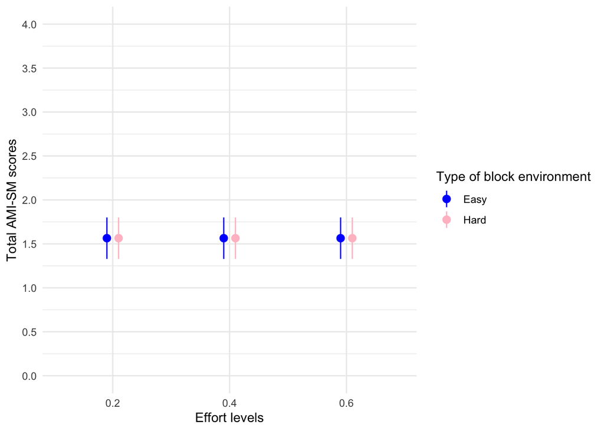

```r
aetv1_plot4 <- ggplot2::ggplot(AET_behandquestn_tib, aes(x = shapeEffort, y= AMI_SM_sum, colour = blockType)) +
  stat_summary(fun.data = "mean_cl_normal", geom = "pointrange", position = position_dodge(width = 0.2)) +
  coord_cartesian(ylim = c(0,4)) +
  scale_y_continuous(breaks = seq(0, 4, 0.5)) +
  labs(x = "Effort levels", y = "Total AMI-SM scores", colour = "Type of block environment") +
  scale_color_manual(values = c("Easy" = "blue", "Hard" = "pink")) +
  theme_minimal()
aetv1_plot4
```

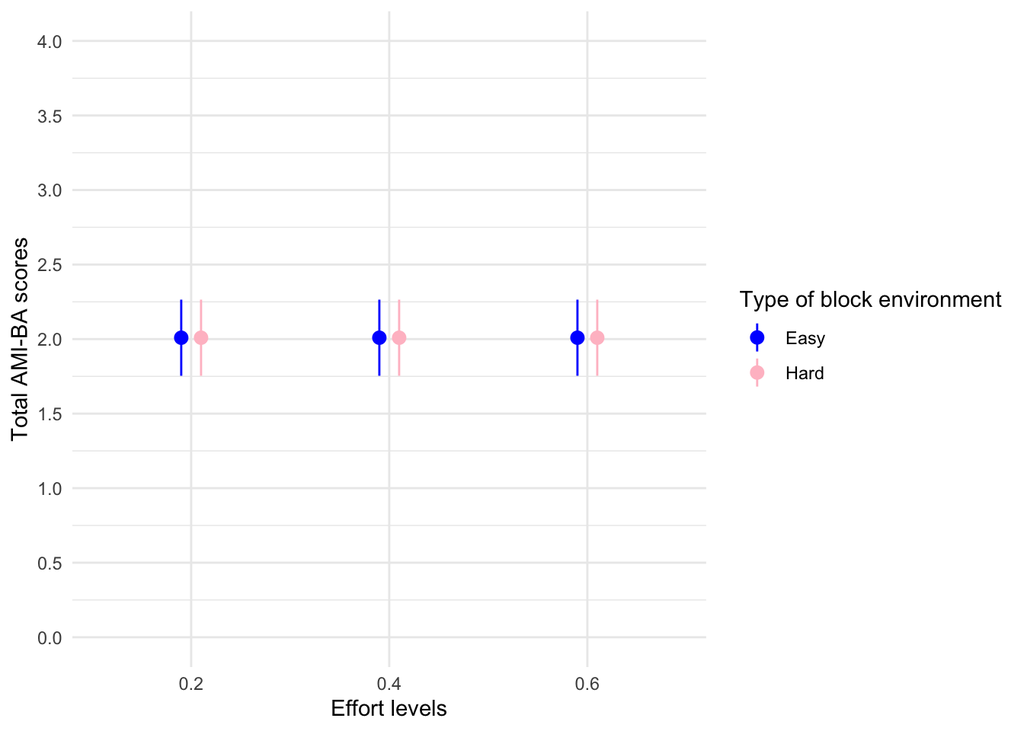

```r
aetv1_plot5 <- ggplot2::ggplot(AET_behandquestn_tib, aes(x = shapeEffort, y= AMI_BA_sum, colour = blockType)) +
  stat_summary(fun.data = "mean_cl_normal", geom = "pointrange", position = position_dodge(width = 0.2)) +
  coord_cartesian(ylim = c(0,4)) +
  scale_y_continuous(breaks = seq(0, 4, 0.5)) +
  labs(x = "Effort levels", y = "Total AMI-BA scores", colour = "Type of block environment") +
  scale_color_manual(values = c("Easy" = "blue", "Hard" = "pink")) +
  theme_minimal()
aetv1_plot5
```

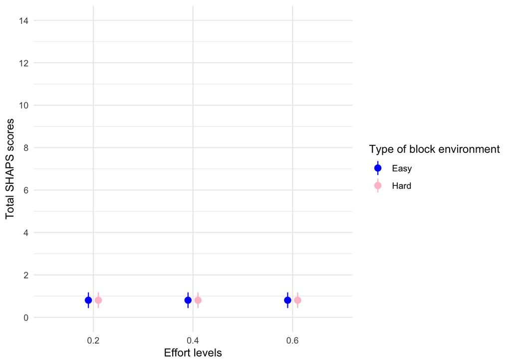

```r
#SHAPS (Table)
mean_aetv1_SHAPS <- AET_behandquestn_tib %>%
  dplyr::group_by(blockType, shapeEffort) %>%
  dplyr::summarize(
    n = n(),
    mean_SHAPS = mean(SHAPS_sum),
    LCI_SHAPS = ggplot2::mean_cl_normal(SHAPS_sum)$ymin,
    UCI_SHAPS = ggplot2::mean_cl_normal(SHAPS_sum)$ymax
  )

#Mean plot- SHAPS
aetv1_plot6 <- ggplot2::ggplot(AET_behandquestn_tib, aes(x = shapeEffort, y= SHAPS_sum, colour = blockType)) +
  stat_summary(fun.data = "mean_cl_normal", geom = "pointrange", position = position_dodge(width = 0.2)) +
  coord_cartesian(ylim = c(0,14)) +
  scale_y_continuous(breaks = seq(0, 14, 2)) +
  labs(x = "Effort levels", y = "Total SHAPS scores", colour = "Type of block environment") +
  scale_color_manual(values = c("Easy" = "blue", "Hard" = "pink")) +
  theme_minimal()
aetv1_plot6
```

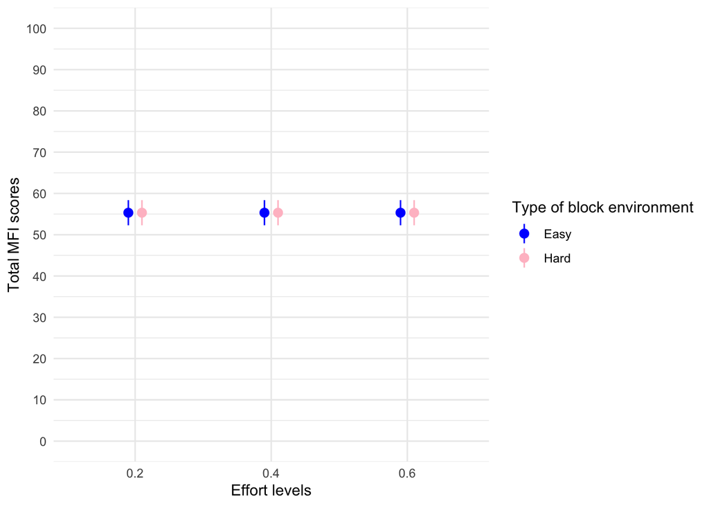

```r
#MFI and sub-scales (Table)
mean_aetv1_MFI <- AET_behandquestn_tib %>%
  dplyr::group_by(blockType, shapeEffort) %>%
  dplyr::summarize(
    n = n(),
    mean_MFI = mean(MFI_sum),
    LCI_MFI = ggplot2::mean_cl_normal(MFI_sum)$ymin,
    UCI_MFI = ggplot2::mean_cl_normal(MFI_sum)$ymax,
    mean_MFI_GF = mean(MFI_genfatigue_sum),
    LCI_MFI_GF = ggplot2::mean_cl_normal(MFI_genfatigue_sum)$ymin,
    UCI_MFI_GF = ggplot2::mean_cl_normal(MFI_genfatigue_sum)$ymax,
    mean_MFI_PF = mean(MFI_phyfatigue_sum),
    LCI_MFI_PF = ggplot2::mean_cl_normal(MFI_phyfatigue_sum)$ymin,
    UCI_MFI_PF = ggplot2::mean_cl_normal(MFI_phyfatigue_sum)$ymax,
    mean_MFI_RA = mean(MFI_redactivity_sum),
    LCI_MFI_RA = ggplot2::mean_cl_normal(MFI_redactivity_sum)$ymin,
    UCI_MFI_RA = ggplot2::mean_cl_normal(MFI_redactivity_sum)$ymax,
    mean_MFI_RM = mean(MFI_redmotn_sum),
    LCI_MFI_RM = ggplot2::mean_cl_normal(MFI_redmotn_sum)$ymin,
    UCI_MFI_RM = ggplot2::mean_cl_normal(MFI_redmotn_sum)$ymax,
    mean_MFI_MF = mean(MFI_mentalfatigue_sum),
    LCI_MFI_MF = ggplot2::mean_cl_normal(MFI_mentalfatigue_sum)$ymin,
    UCI_MFI_MF = ggplot2::mean_cl_normal(MFI_mentalfatigue_sum)$ymax
  )

#Mean plot- MFI
aetv1_plot7 <- ggplot2::ggplot(AET_behandquestn_tib, aes(x = shapeEffort, y= MFI_sum, colour = blockType)) +
  stat_summary(fun.data = "mean_cl_normal", geom = "pointrange", position = position_dodge(width = 0.2)) +
  coord_cartesian(ylim = c(0,100)) +
  scale_y_continuous(breaks = seq(0, 100, 10)) +
  labs(x = "Effort levels", y = "Total MFI scores", colour = "Type of block environment") +
  scale_color_manual(values = c("Easy" = "blue", "Hard" = "pink")) +
  theme_minimal()
aetv1_plot7
```

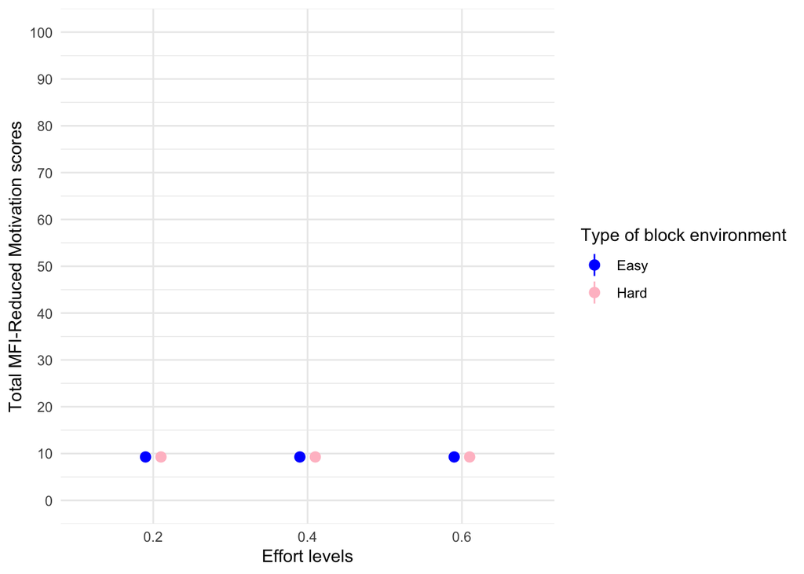

```r
aetv1_plot8 <- ggplot2::ggplot(AET_behandquestn_tib, aes(x = shapeEffort, y= MFI_redmotn_sum, colour = blockType)) +
  stat_summary(fun.data = "mean_cl_normal", geom = "pointrange", position = position_dodge(width = 0.2)) +
  coord_cartesian(ylim = c(0,100)) +
  scale_y_continuous(breaks = seq(0, 100, 10)) +
  labs(x = "Effort levels", y = "Total MFI-Reduced Motivation scores", colour = "Type of block environment") +
  scale_color_manual(values = c("Easy" = "blue", "Hard" = "pink")) +
  theme_minimal()
aetv1_plot8
```

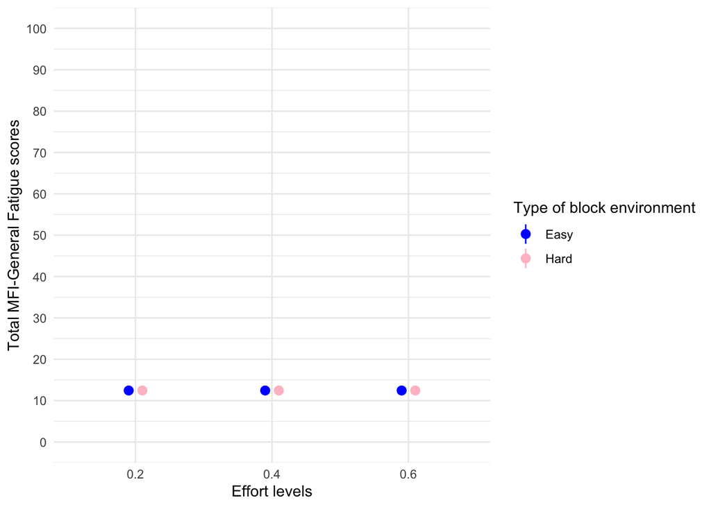

```r
aetv1_plot9 <- ggplot2::ggplot(AET_behandquestn_tib, aes(x = shapeEffort, y= MFI_genfatigue_sum, colour = blockType)) +
  stat_summary(fun.data = "mean_cl_normal", geom = "pointrange", position = position_dodge(width = 0.2)) +
  coord_cartesian(ylim = c(0,100)) +
  scale_y_continuous(breaks = seq(0, 100, 10)) +
  labs(x = "Effort levels", y = "Total MFI-General Fatigue scores", colour = "Type of block environment") +
  scale_color_manual(values = c("Easy" = "blue", "Hard" = "pink")) +
  theme_minimal()
aetv1_plot9
```

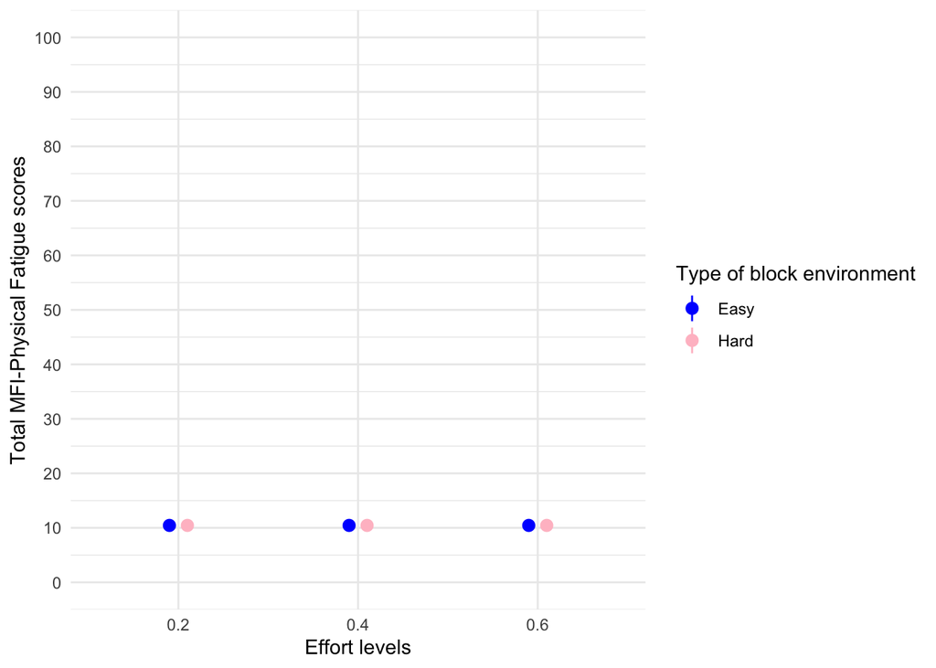

```r
aetv1_plot10 <- ggplot2::ggplot(AET_behandquestn_tib, aes(x = shapeEffort, y= MFI_phyfatigue_sum, colour = blockType)) +
  stat_summary(fun.data = "mean_cl_normal", geom = "pointrange", position = position_dodge(width = 0.2)) +
  coord_cartesian(ylim = c(0,100)) +
  scale_y_continuous(breaks = seq(0, 100, 10)) +
  labs(x = "Effort levels", y = "Total MFI-Physical Fatigue scores", colour = "Type of block environment") +
  scale_color_manual(values = c("Easy" = "blue", "Hard" = "pink")) +
  theme_minimal()
aetv1_plot10
```

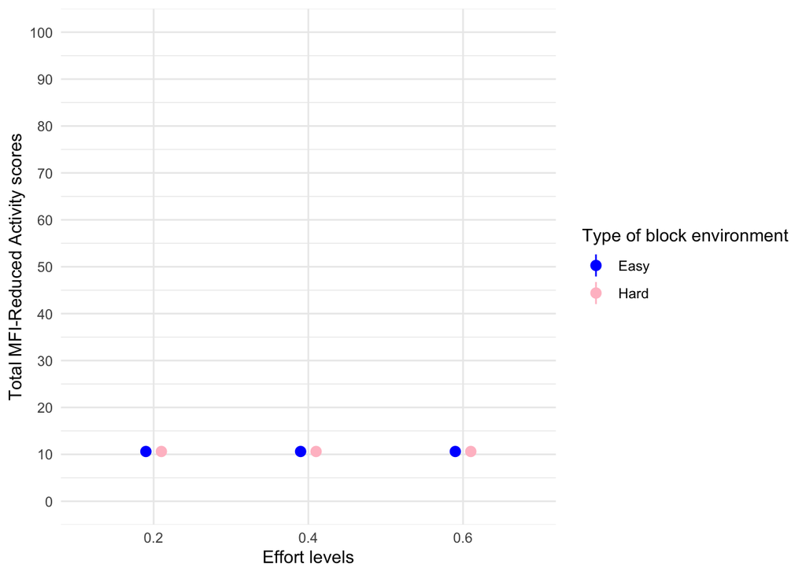

```r
aetv1_plot11 <- ggplot2::ggplot(AET_behandquestn_tib, aes(x = shapeEffort, y= MFI_redactivity_sum, colour = blockType)) +
  stat_summary(fun.data = "mean_cl_normal", geom = "pointrange", position = position_dodge(width = 0.2)) +
  coord_cartesian(ylim = c(0,100)) +
  scale_y_continuous(breaks = seq(0, 100, 10)) +
  labs(x = "Effort levels", y = "Total MFI-Reduced Activity scores", colour = "Type of block environment") +
  scale_color_manual(values = c("Easy" = "blue", "Hard" = "pink")) +
  theme_minimal()
aetv1_plot11
```

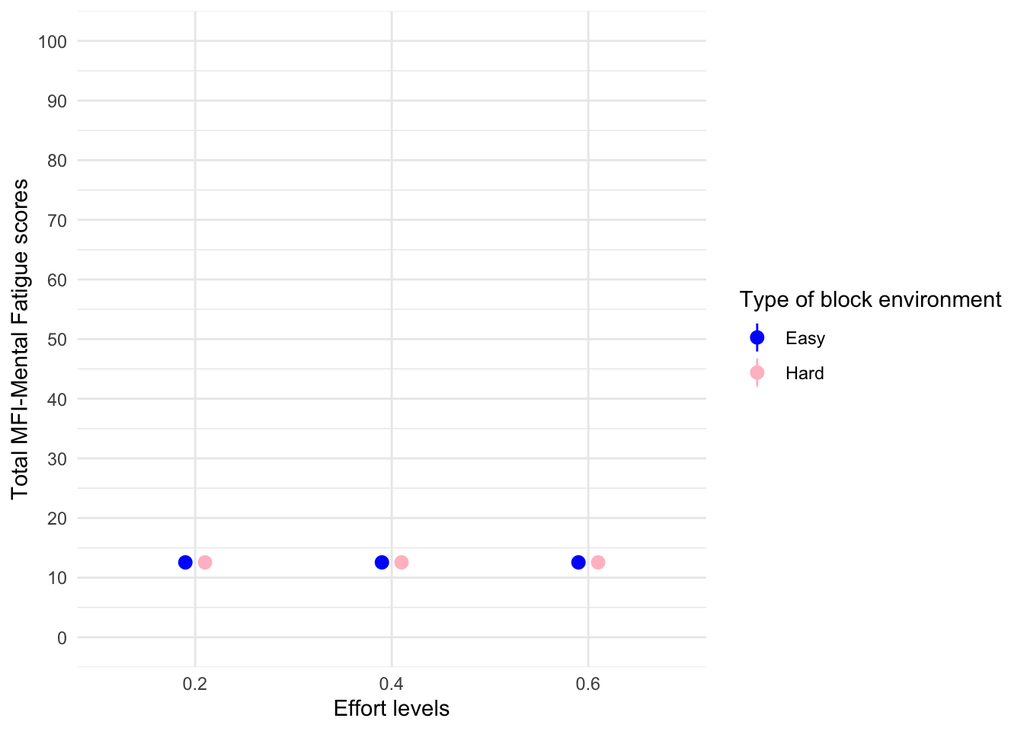

```r
aetv1_plot12 <- ggplot2::ggplot(AET_behandquestn_tib, aes(x = shapeEffort, y= MFI_mentalfatigue_sum, colour = blockType)) +
  stat_summary(fun.data = "mean_cl_normal", geom = "pointrange", position = position_dodge(width = 0.2)) +
  coord_cartesian(ylim = c(0,100)) +
  scale_y_continuous(breaks = seq(0, 100, 10)) +
  labs(x = "Effort levels", y = "Total MFI-Mental Fatigue scores", colour = "Type of block environment") +
  scale_color_manual(values = c("Easy" = "blue", "Hard" = "pink")) +
  theme_minimal()
aetv1_plot12
```

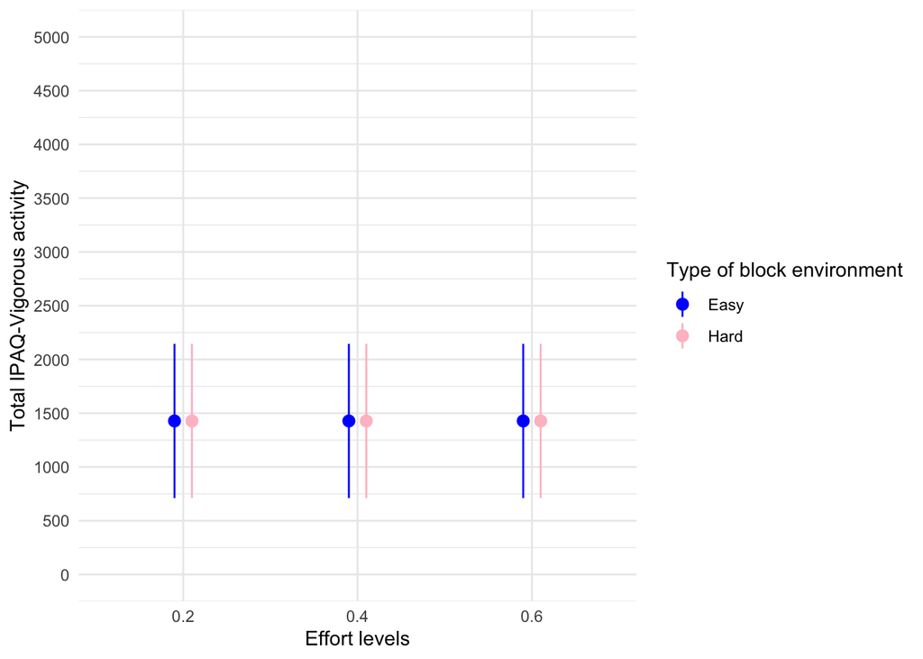

```r
#Mean plot- IPAQ
aetv1_plot13 <- ggplot2::ggplot(AET_behandquestn_tib, aes(x = shapeEffort, y= IPAQ_vigorous, colour = blockType), na.rm = T) +
  stat_summary(fun.data = "mean_cl_normal", geom = "pointrange", position = position_dodge(width = 0.2)) +
  coord_cartesian(ylim = c(0,5000)) +
  scale_y_continuous(breaks = seq(0, 5000, 500)) +
  labs(x = "Effort levels", y = "Total IPAQ-Vigorous activity", colour = "Type of block environment") +
  scale_color_manual(values = c("Easy" = "blue", "Hard" = "pink")) +
  theme_minimal()
aetv1_plot13
```

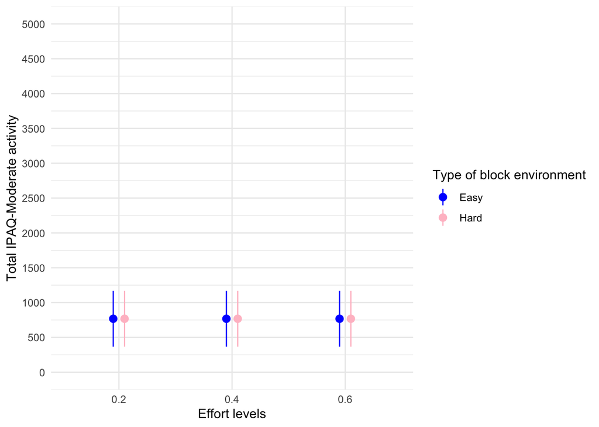

```r
aetv1_plot14 <- ggplot2::ggplot(AET_behandquestn_tib, aes(x = shapeEffort, y= IPAQ_moderate, colour = blockType)) +
  stat_summary(fun.data = "mean_cl_normal", geom = "pointrange", position = position_dodge(width = 0.2)) +
  coord_cartesian(ylim = c(0,5000)) +
  scale_y_continuous(breaks = seq(0, 5000, 500)) +
  labs(x = "Effort levels", y = "Total IPAQ-Moderate activity", colour = "Type of block environment") +
  scale_color_manual(values = c("Easy" = "blue", "Hard" = "pink")) +
  theme_minimal()
aetv1_plot14
```

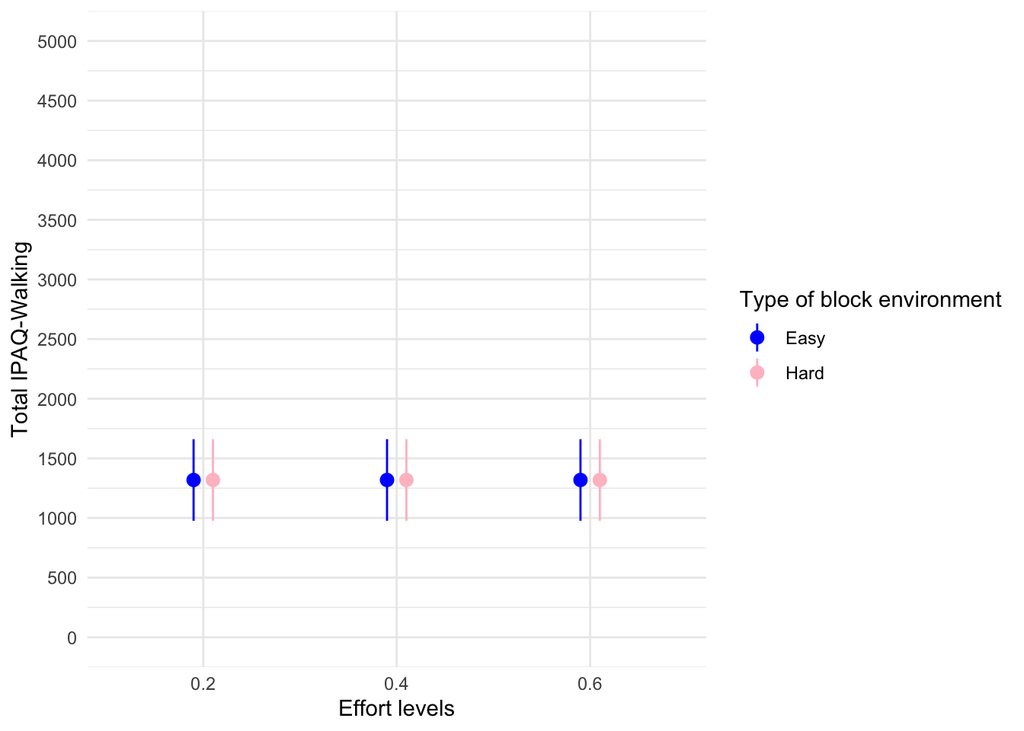

```r
aetv1_plot15 <- ggplot2::ggplot(AET_behandquestn_tib, aes(x = shapeEffort, y= IPAQ_walking, colour = blockType)) +
  stat_summary(fun.data = "mean_cl_normal", geom = "pointrange", position = position_dodge(width = 0.2)) +
  coord_cartesian(ylim = c(0,5000)) +
  scale_y_continuous(breaks = seq(0, 5000, 500)) +
  labs(x = "Effort levels", y = "Total IPAQ-Walking", colour = "Type of block environment") +
  scale_color_manual(values = c("Easy" = "blue", "Hard" = "pink")) +
  theme_minimal()
aetv1_plot15
```

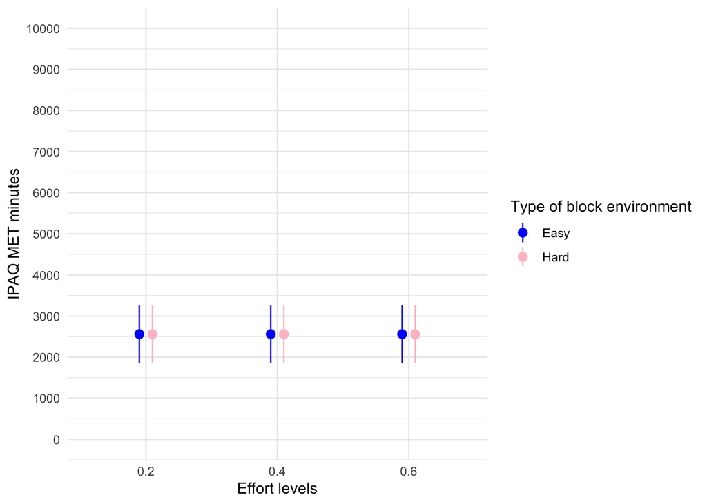

```r
aetv1_plot16 <- ggplot2::ggplot(AET_behandquestn_tib, aes(x = shapeEffort, y= IPAQ_MET, colour = blockType)) +
  stat_summary(fun.data = "mean_cl_normal", geom = "pointrange", position = position_dodge(width = 0.2)) +
  coord_cartesian(ylim = c(0,10000)) +
  scale_y_continuous(breaks = seq(0, 10000, 1000)) +
  labs(x = "Effort levels", y = "IPAQ MET minutes", colour = "Type of block environment") +
  scale_color_manual(values = c("Easy" = "blue", "Hard" = "pink")) +
  theme_minimal()
aetv1_plot16
```

## Boxplots

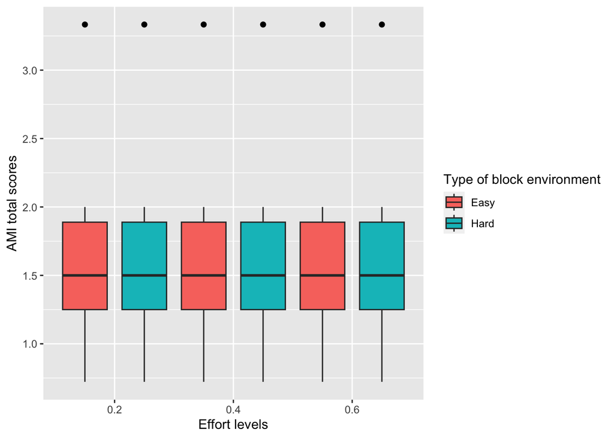

```r
library(ggplot2)

AET_behandquestn_tib$shapeEffort <- as.factor(AET_behandquestn_tib$shapeEffort)

boxplot1<-ggplot(AET_behandquestn_tib, aes(x=shapeEffort, y=AMI_sum, fill=blockType)) +
  geom_boxplot(position=position_dodge(1), outlier.colour="black", outlier.shape=16,
             outlier.size=2) +
  labs(x = "Effort levels", y = "AMI total scores", fill = "Type of block environment")
boxplot1
```

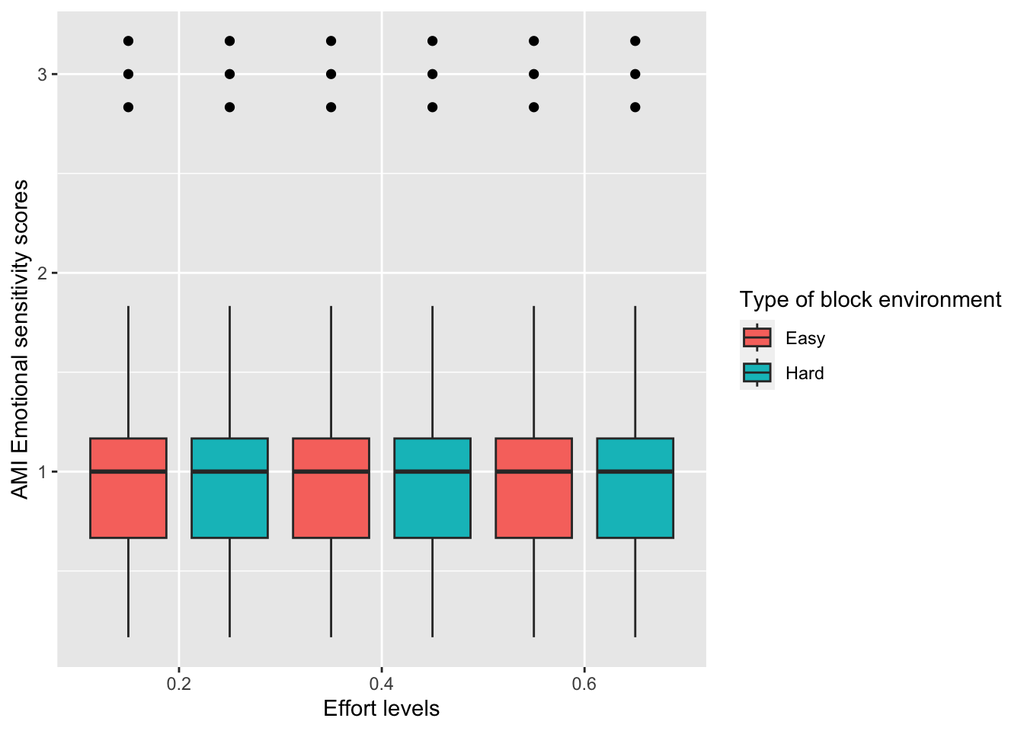

```r
boxplot2<-ggplot(AET_behandquestn_tib, aes(x=shapeEffort, y=AMI_ES_sum, fill=blockType)) +
  geom_boxplot(position=position_dodge(1), outlier.colour="black", outlier.shape=16,
             outlier.size=2) +
  labs(x = "Effort levels", y = "AMI Emotional sensitivity scores", fill = "Type of block environment")
boxplot2
```

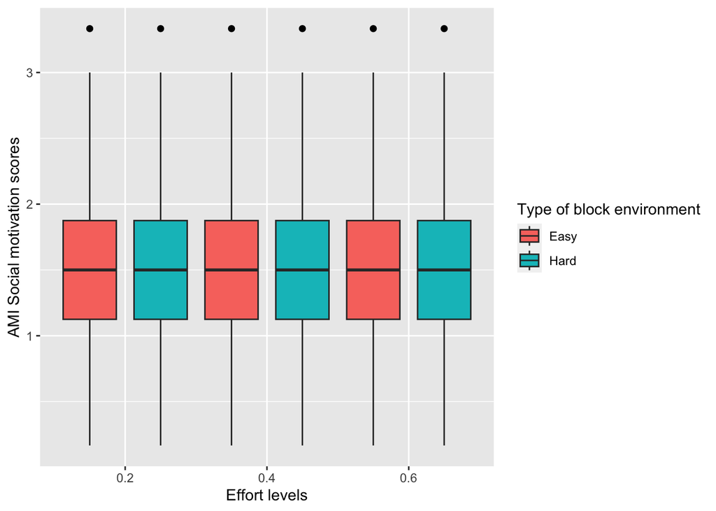

```r
boxplot3<-ggplot(AET_behandquestn_tib, aes(x=shapeEffort, y=AMI_SM_sum, fill=blockType)) +
  geom_boxplot(position=position_dodge(1), outlier.colour="black", outlier.shape=16,
             outlier.size=2) +
  labs(x = "Effort levels", y = "AMI Social motivation scores", fill = "Type of block environment")
boxplot3
```